# Eegmanypipelines

Stefan Wiens

2022-05-10

# packages

**R version 4.1.3 (2022-03-10)**

```r
# packages on CRAN
packages <- c(
    "ggplot2",
    "dplyr",
    "readr",
    "stringr",
    "tibble",
    "tidyr",
    "kableExtra",   # nice tables
    #"gridExtra",   # combine different ggplots
    "broom.mixed",  # extracting data from model fits
    "insight",      # access model info
    # Bayesian
    "see",          # half violin, BF
    "brms",         # Bayesian regression modeling
    "bayestestR",   # Bayes indexes
    "bayesplot",
    "report")       # references for packages

# Install packages not yet installed
installed_packages <- packages %in% rownames(installed.packages())
if (any(installed_packages == FALSE)) {
  install.packages(packages[!installed_packages], repos = c(CRAN = "https://cran.rstudio.com"))
}
# Packages loading
invisible(lapply(packages, library, character.only = TRUE))

packv <- NULL
for (i in 1:length(packages)) {
  packv = rbind(packv, c(packages[i], as.character(packageVersion(packages[i]))))
}
colnames(packv) <- c("Package", "Version")
packv %>%
  as_tibble %>%
  arrange(Package) %>%
  kable(align = "l") %>%
  kable_styling(bootstrap_options = c("striped", "hover", "condensed"))
```

| Package | Version |
| --- | --- |
| bayesplot | 1.9.0 |
| bayestestR | 0.11.5 |
| brms | 2.16.3 |
| broom.mixed | 0.2.9.3 |
| dplyr | 1.0.8 |
| ggplot2 | 3.3.5 |
| insight | 0.17.0 |
| kableExtra | 1.3.4 |
| readr | 2.1.2 |
| report | 0.5.1 |
| see | 0.7.0 |
| stringr | 1.4.0 |
| tibble | 3.1.6 |
| tidyr | 1.2.0 |

```r
# use all cores for Bayesian analyses
options(mc.cores = parallel::detectCores()) # use all cores
```

# background

parameter defines which hypothesis is supposed to be tested from this set.

**h1**

- `category`: scene category (`man-made` vs `natural`)
- `h1_N1`: mean amplitude (call with: **h1_N1**)

**h2**

- `novelty`: image novelty (`new` vs `old`)
- `h2_amp`: fronto-central mean amplitude (call with: **h2_amp**)
- `h2_theta`: fronto-central theta (call with: **h2_theta**)
- `h2_alpha`: posterior alpha (call with: **h2_alpha**)

**h3**

- `recognition`: successful recognition (`hit` vs `miss`)
- `h3_amp`: mean amplitude any channel any time (call with: **h3_amp**)
- `h3_spectral`: spectral any freq, channel, and time (call with: **h3_spectral**)

**h4**

- `memory`: subsequent memory (`remembered` vs `forgotten`)
- `h4_amp`: mean amplitude any channel any time (call with: **h4_amp**)
- `h4_spectral`: spectral any freq, channel, and time (call with: **h4_spectral**)

```r
now_h <- params$now_h
now_stage <- params$now_stage
now_num <- NA     # order of hypothesis in instruction document (helps in output file)
now_text <- NA    # info about hypothesis
now_cond <- NA    # predictor variable (always has 2 levels)
now_levels <- NA  # name of levels of predictor variable

# effect coding
# =============
# - if you use [-1, +1], the estimates change (but not p values).
# This is because the predictors are scaled differently.
# - this centers the predictors
# - the second level becomes the baseline in the model
now_contrasts <- c(0.5, -0.5)
now_EEG <- NA     # outcome variable
now_exclude_bad <- "N"  # Y/N: exclude trials labeled as bad during preprocessing

# (To avoid biases of initial (MNE) EEG figures, we eyeballed the data and
# screened for extreme values. However, these are included here because below,
# outliers are detected across all trials and robust methods are used. The
# criterion defines the number of SD around each condition mean that are not
# considered outliers.)
now_outcut <- 3 # eg 3 means values have to be more than 3 SDs from the condition mean

now_ROPE <- c(-.1, .1)    # region of practical equivalence

# default prior:
# normal distribution with m = 0 and sd = 2
now_prior <- brms::prior_string("normal(0,2)", class = "b")

# stage 2 may use prior from stage 1; default is no
now_s2_use_s1_prior <- "N" # Y/N to tell stage 2 to use the prior from stage 1

# scaling factor for the posterior sd in stage 2
# taking the sd from the posterior in stage 1 as the prior in stage 2 may be too optimistic
# multiply the obtained sd of posterior by the scaling factor
now_scaling <- 3 # default in bayestestR
```

```r
# h1: category
if (now_h == "h1_N1"){
  now_num <- 1
  now_text <- ("There is an effect of scene category (i.e., a difference between images\nshowing man-made vs. natural environments) on the amplitude of the\nN1 component, i.e. the first major negative EEG voltage deflection.")
  now_cond <- "category"
  now_levels <- c("man-made", "natural")
  now_EEG  <- "h1_N1"

# h2: novelty
} else if (now_h == "h2_amp"){
  now_num <- 2
  now_text <- ("There are effects of image novelty (i.e., between images shown for the first\ntime/new vs. repeated/old images) within the time-range from 300–500 ms on\nEEG voltage at fronto-central channels.")
  now_cond <- "novelty"
  now_levels <- c("new", "old")
  now_EEG  <- "h2_amp"

} else if (now_h == "h2_theta"){
  now_num <- 3
  now_text <- ("There are effects of image novelty (i.e., between images shown for the first\ntime/new vs. repeated/old images) within the time-range from 300–500 ms on\ntheta power at fronto-central channels.")
  now_cond <- "novelty"
  now_levels <- c("new", "old")
  now_EEG  <- "h2_theta"

} else if (now_h == "h2_alpha"){
  now_num <- 4
  now_text <- ("There are effects of image novelty (i.e., between images shown for the first\ntime/new vs. repeated/old images) within the time-range from 300–500 ms on\nalpha power at posterior channels.")
  now_cond <- "novelty"
  now_levels <- c("new", "old")
  now_EEG  <- "h2_alpha"

# h3: recognition
} else if (now_h == "h3_amp"){
  now_num <- 5
  now_text <- ("There are effects of successful recognition of old images (i.e., a difference\nbetween old images correctly recognized as old [hits] vs. old images\nincorrectly judged as new [misses]) on\nEEG voltage at any channels, at any time.")
  now_cond <- "recognition"
  now_levels <- c("hit", "miss")
  now_EEG  <- "h3_amp"

} else if (now_h == "h3_spectral"){
  now_num <- 6
  now_text <- ("There are effects of successful recognition of old images (i.e., a difference\nbetween old images correctly recognized as old [hits] vs. old images\nincorrectly judged as new [misses]) on\nEEG voltage at any channels, at any time.")
  now_cond <- "recognition"
  now_levels <- c("hit", "miss")
  now_EEG  <- "h3_spectral"

# h4: memory
} else if (now_h == "h4_amp"){
  now_num <- 7
  now_text <- ("There are effects of subsequent memory (i.e., a difference between images that\nwill be successfully remembered vs. forgotten on a subsequent repetition) on\nEEG voltage at any channels, at any time.")
  now_cond <- "memory"
  now_levels <- c("remembered", "forgotten")
  now_EEG  <- "h4_amp"

} else if (now_h == "h4_spectral"){
  now_num <- 8
  now_text <- ("There are effects of subsequent memory (i.e., a difference between images that\nwill be successfully remembered vs. forgotten on a subsequent repetition) on\nspectral power, at any frequencies, at any channels, at any time.")
  now_cond <- "memory"
  now_levels <- c("remembered", "forgotten")
  now_EEG  <- "h4_spectral"
}
```

# **h4_amp – stage 3**

hypothesis: **h4_amp**

stage: **3**

goal: There are effects of subsequent memory (i.e., a difference between images that will be successfully remembered vs. forgotten on a subsequent repetition) on EEG voltage at any channels, at any time.

condition: memory

EEG: h4_amp

definition of EEG variable:

```r
# read outcome specifications
df_outcome_spec <- read_delim("data/outcome_specifications.tsv", delim = "\t",
                        show_col_types = FALSE) %>%
  filter(hypothesis == now_h) %>%
  pivot_longer(cols = 2:4, names_to = "Feature", values_to = "Value") %>%
  select(-hypothesis)
df_outcome_spec %>%
  kable(align = "l") %>%
  kable_styling(bootstrap_options = c("striped", "hover", "condensed"))
```

| Feature | Value |
| --- | --- |
| interval (ms) | 160 - 210 |
| electrodes | P1, P3, P5, P7, P9, PO7, PO3, O1 |
| frequency | NA |

trials identified as bad during preprocessing are excluded (Y/N): N

outlier cutoff: 3 x SD

(To avoid biases of initial (MNE) EEG figures, we eyeballed the data and screened for extreme values. However, these are included here because below, outliers are detected across all trials and robust methods are used. The criterion defines the number of SD around each condition mean that are not considered outliers.)

ROPE (region of practical equivalence): -0.1, 0.1

```r
# if stage 2 is supposed to use prior from stage 1, read it from file
if ((now_s2_use_s1_prior == "Y") && now_stage == 2){
  # check for prior from stage 1
  stopifnot("No file with priors is available" =
            file.exists("results/prior_posterior.txt"))
  # read in prior
  df_distr <- read_delim("results/prior_posterior.txt", delim = "\t",
                          show_col_types = FALSE)
  # find row for hypothesis and stage 1
  df_distr$check <- (df_distr$Hypothesis == now_h) &
                    (df_distr$Stage == 1)

  # keep this row
  df_distr <- df_distr %>%
    filter(df_distr$check) %>%
    select(-check)

  stopifnot("No prior saved from stage 1" = nrow(df_distr) > 0)
  stopifnot("Too many priors saved from stage 1" = nrow(df_distr) == 1)

  # redefine prior
  now_prior <- prior_string(paste0("normal(",
                      round(df_distr$Posterior_m, 2), ", ",
                      # maybe rescale posterior to make it wider
                      round(df_distr$Posterior_sd * now_scaling, 2), ")"), class = "b")
}
```

# define settings

seed, iterations, warm up for models

```r
# ensure the model returns the same result on each run
nowseed <- sum(as.integer(iconv(paste0(now_h, now_stage), toRaw = TRUE)[[1]]))

my_iter <- 2000
my_warm <- 1000

# ggplot theme
theme_set(theme_bw())
```

- seed = 620
- number of iterations = 2000
- number of warm-ups = 1000

# references

for Bayesian analysis:

Franke, M., & Roettger, T. B. (2019). Bayesian regression modeling (for factorial designs): A tutorial. PsyArXiv. https://doi.org/10.31234/osf.io/cdxv3

Makowski, D., Ben-Shachar, M. S., Chen, S. H. A., & Lüdecke, D. (2019). Indices of Effect Existence and Significance in the Bayesian Framework. Frontiers in Psychology, 10, 2767. https://doi.org/10.3389/fpsyg.2019.02767

for robust Bayesian analysis:

Alday, P. M., & van Paridon, J. (2021). Away from arbitrary thresholds: Using robust statistics to improve artifact rejection in ERP [Preprint]. PsyArXiv. https://doi.org/10.31234/osf.io/wqrb5

for two-stage analysis:

Stefan, A., Lengersdorff, L., & Wagenmakers, E.-J. (2022). A two-stage Bayesian sequential assessment of exploratory hypotheses [Preprint]. PsyArXiv. https://doi.org/10.31234/osf.io/qwuyf

# read data

input:

- `fp` = subject id
- `trial` = trial
- `cond` = condition codes (e.g., man-made/new/correct rejection/forgotten)
- `bad` (1 or 0) = 1: artifact rejection in MNE labeled as bad
- lots of outcome variables

```r
df <- read_tsv(file = "data/data.tsv", show_col_types = FALSE) %>%
  rowwise() %>%
  mutate(condlist = str_split(cond, "/"),
        category = condlist[1],
        novelty = condlist[2],
        recognition = condlist[3],
        memory = condlist[4]) %>%
  ungroup() %>%
  mutate(na_if(across(category:memory),"NA")) %>%
  select(-condlist)

if (now_exclude_bad == "Y") {
  df <- df %>%
    filter(bad == 0)
}

# select sample
# stage1 shows whether subject was randomly selected to be in the subsample (ie Stage 1):
#   1 = subject is in Stage 1
#   0 = subject is not in Stage 1
if (now_stage == 1){
  # stage1 (keep small subset of subjects)
  df <- df %>%
        filter(stage1 == 1)
} else if (now_stage == 2){
  # stage2 (keep remaining subjects)
  df <- df %>%
        filter(stage1 == 0)
} else {
  # use all subjects
  stopifnot("Stage must be between 1 and 3!" = now_stage == 3)
}

# keep relevant columns
df <- df %>%
  select(id, trial, cond, bad, all_of(now_cond), all_of(now_EEG))
  # why all_of? see https://tidyselect.r-lib.org/reference/faq-external-vector.html

# define comparison as factor
df[[now_cond]] <- factor(df[[now_cond]], levels = now_levels)
contrasts(df[[now_cond]]) <- now_contrasts

# add copy of relevant variables
# easier for plotting
df$now_compare <- df[[now_cond]]
df$EEG <- df[[now_EEG]]

# keep only relevant trials
df <- df %>%
  filter(!is.na(now_compare))
```

# sample

number of subjects = **33**.

```r
table(df[[now_cond]], dnn = str_to_title(now_cond))
```

```
## Memory
## remembered  forgotten
##      15234       4071
```

# outliers

criterion was defined initially as **3** x SD

zscore is computed for each EEG value in reference to its own condition mean. The criterion refers to numbers of SDs around its own condition mean that are not considered outliers

## raw data

include outliers

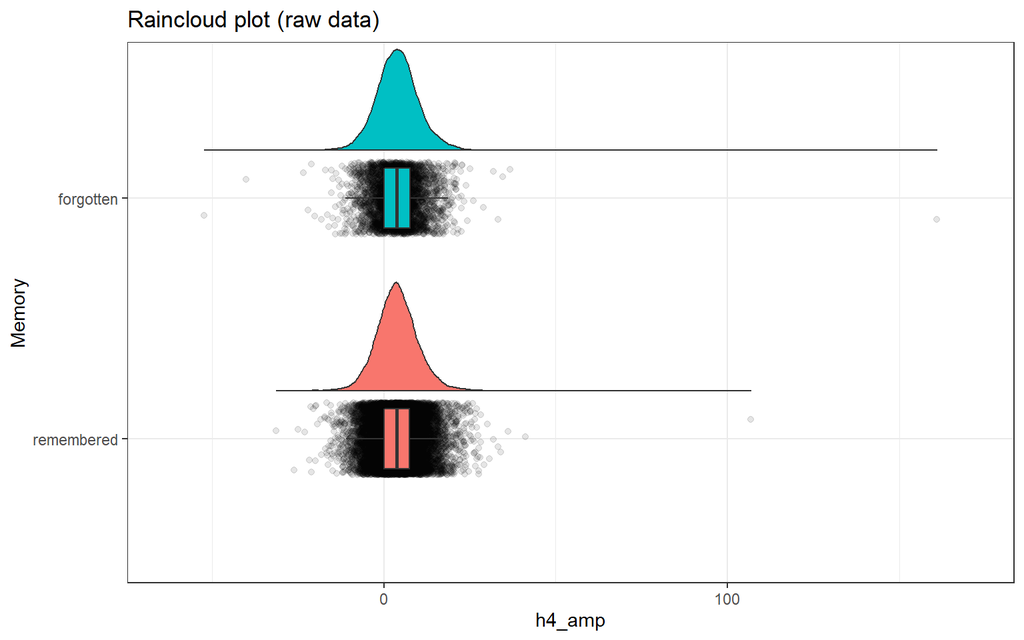

```r
# plot Raincloud and boxplot
tmpplot <- df %>%
  ggplot(aes(x = now_compare, y = EEG, fill = now_compare)) +
  geom_violinhalf(position = position_nudge(x = .2, y = 0)) +
  coord_flip() +
  geom_jitter(width = 0.15, alpha = 0.1) +
  geom_boxplot(width = .25,  outlier.shape = NA ) +
  theme(legend.position = "none") +
  labs(title = "Raincloud plot (raw data)",
       x = str_to_title(now_cond),
       y = now_EEG)
# save x axis range
tmpxlim <- ggplot_build(tmpplot)$layout$panel_params[[1]]$x.range
tmpplot + scale_y_continuous(limits = tmpxlim)
```

## check distribution

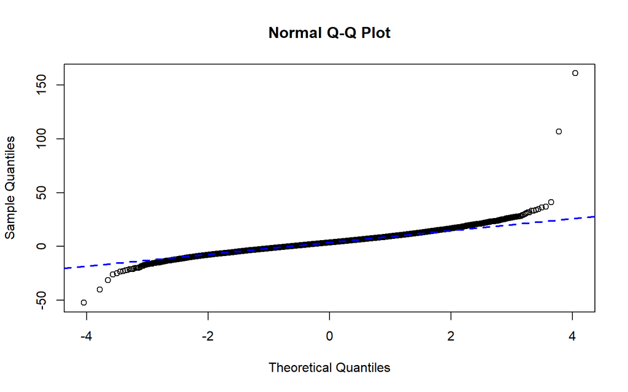

```r
qqnorm(df$EEG)
qqline(df$EEG, col = "blue", lwd = 2, lty = 2)
```

```r
shapiro.test(sample(df$EEG,
             # 5000 is max for Shapiro test
             5000, replace = FALSE))
```

```
##
##  Shapiro-Wilk normality test
##
## data:  sample(df$EEG, 5000, replace = FALSE)
## W = 0.99241, p-value = 1.065e-15
```

```r
# for transformation advice, see here
# https://r-coder.com/box-cox-transformation-r/

# make positive
x <- df$EEG - min(df$EEG) + .01
cat("For some of the spectral analyses, the data do not look normally distributed but skewed.\nFor completeness, conduct a boxcox transformation for the frequency data.\nStart by computing lambda.")
MASS::boxcox(lm(x ~ 1, y = TRUE))
bc <- MASS::boxcox(lm(x ~ 1, y = TRUE))
lambda <- bc$x[which.max(bc$y)]
df$EEGlambda <-  (x ^ lambda - 1) / lambda
cat("The figure suggests some deviation from a normal distribution.\nA Boxcox transformation was computed (after shifting the values to positive).\nThe best lambda was ", round(lambda,2), ".\n\nIf lambda is close to 1, the transformation does not change the data much; thus, it is recommended to leave the data as they are.\n\nNonetheless, the data were transformed: \n(1) shifting to positive\n(2) adjusting with exact lambda\n\n", sep ="")

qqnorm(df$EEGlambda, main = "Normal Q-Q Plot after Lambda transformation")
qqline(df$EEGlambda, col = "blue", lwd = 2, lty = 2)

Shapiro_trans <- shapiro.test(sample(df$EEGlambda,
                                 # 5000 is max for Shapiro test
                                 5000, replace = FALSE))
Shapiro_trans$data.name <- "EEG after lambda transformation across conditions"

print(Shapiro_trans)
cat("Because the transformation did not seem to help much, the untransformed data were used in the final analyses.")
df$EEGlambda <- NULL
rm(x)
```

## without outliers

exclude outliers and plot with same x-axis limits

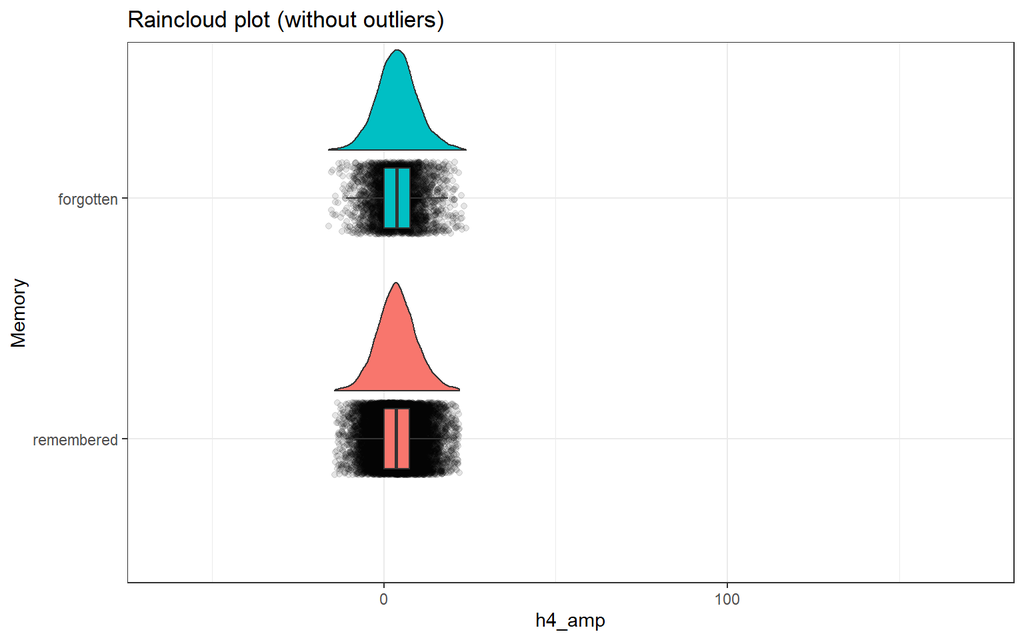

```r
df_tmp <- df %>%
  group_by(now_compare) %>%
  mutate(EEGz = scale(EEG),
         outlier = if_else(abs(EEGz) > now_outcut, 1, 0)) %>%
  ungroup() %>%
  filter(outlier == 0) %>%
  select(-c(EEGz, outlier))
df_tmp %>%
  ggplot(aes(x = now_compare, y = EEG, fill = now_compare)) +
  geom_violinhalf(position = position_nudge(x = .2, y = 0)) +
  coord_flip() +
  geom_jitter(alpha = 0.1, width = 0.15) +
  geom_boxplot(width = .25,  outlier.shape = NA, ) +
  theme(legend.position = "none") +
  scale_y_continuous(limits = tmpxlim) +
  labs(title = "Raincloud plot (without outliers)",
       x = str_to_title(now_cond),
       y = now_EEG)
```

```r
rm(tmpplot, tmpxlim)
```

# remove outliers

with outliers = 19305 trials

without outliers = 19161 trials

thus, 144 trials were removed, and 99.25% of trials were retained.

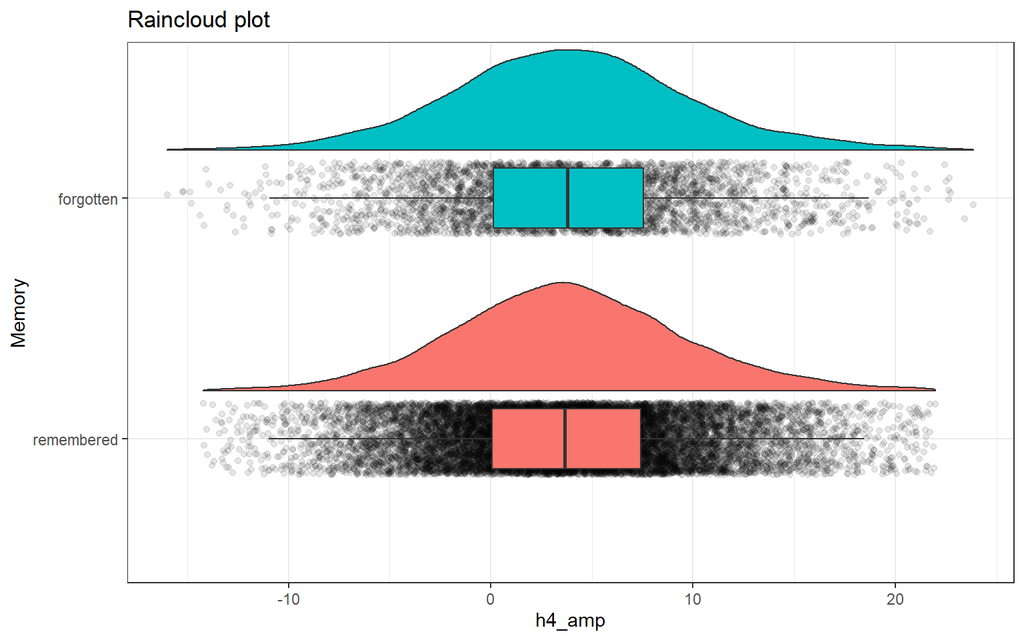

```r
df <- df_tmp
rm(df_tmp)
df %>%
  ggplot(aes(x = now_compare, y = EEG, fill = now_compare)) +
  geom_violinhalf(position = position_nudge(x = .2, y = 0)) +
  coord_flip() +
  geom_jitter(alpha = 0.1, width = 0.15) +
  geom_boxplot(width = .25,  outlier.shape = NA ) +
  theme(legend.position = "none") +
  labs(title = "Raincloud plot",
       x = str_to_title(now_cond),
       y = now_EEG)
```

# check distribution

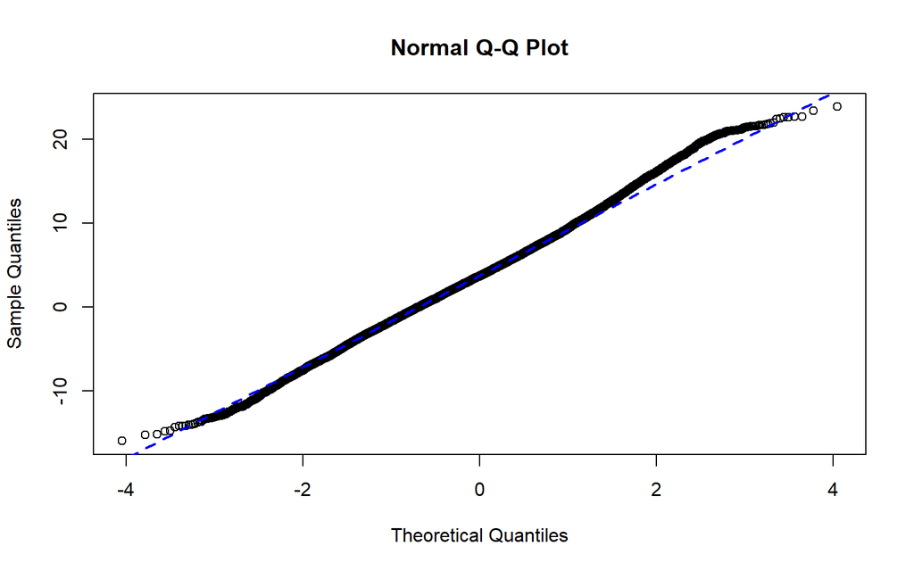

```r
qqnorm(df$EEG)
qqline(df$EEG, col = "blue", lwd = 2, lty = 2)
```

```r
shapiro.test(sample(df$EEG,
             # 5000 is max for Shapiro test
             5000, replace = FALSE))
```

```
##
##  Shapiro-Wilk normality test
##
## data:  sample(df$EEG, 5000, replace = FALSE)
## W = 0.99801, p-value = 4.83e-06
```

# N trials

number of trials per category per subject

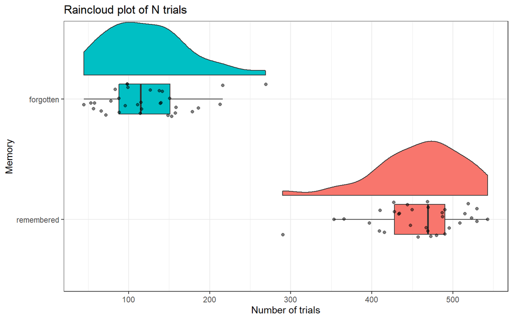

```r
df %>%
  group_by(now_compare, id) %>%
  summarise(N = n(), .groups = "drop") %>%
  ggplot(aes(x = now_compare, y = N, fill = now_compare)) +
  geom_violinhalf(position = position_nudge(x = .2, y = 0)) +
  coord_flip() +
  geom_boxplot(width = .25, outlier.shape = NA ) +
  geom_jitter(alpha = 0.5, width = 0.15) +
  theme(legend.position = "none") +
  labs(title = "Raincloud plot of N trials",
       x = str_to_title(now_cond),
       y = "Number of trials")
```

# **memory** plot

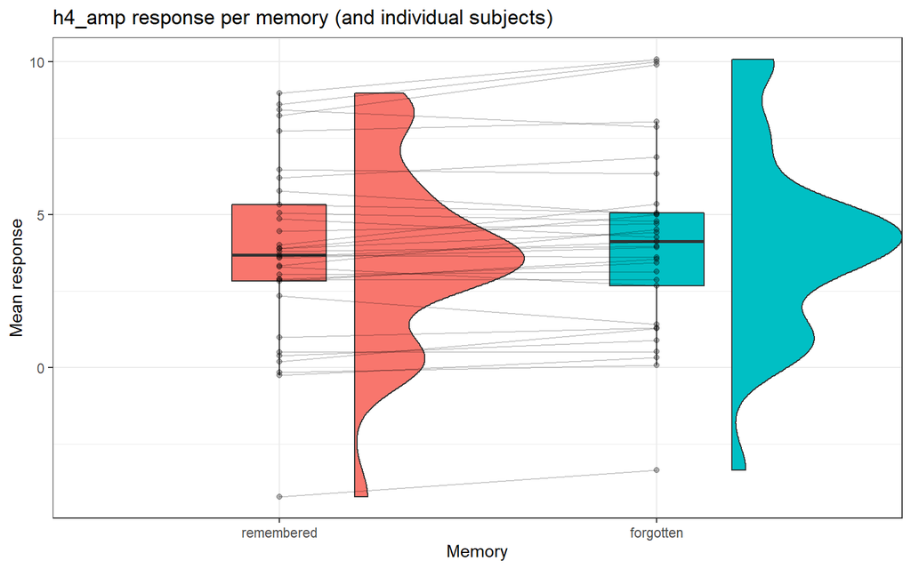

```r
df %>%
  group_by(now_compare, id) %>%
  summarise(amps = mean(EEG), .groups = "drop") %>%
  ggplot(aes(x = now_compare, y = amps, fill = now_compare)) +
  geom_violinhalf(position = position_nudge(x = .2, y = 0)) +
  #coord_flip() +
  geom_boxplot(width = .25, outlier.shape = NA ) +
  geom_jitter(alpha = 0.3, width = 0) +
  theme(legend.position = "none") +
  geom_line(aes(group = id), alpha = 0.2) +
  labs(title = paste0(now_EEG, " response per ", now_cond, " (and individual subjects)"),
       x = str_to_title(now_cond),
       y = "Mean response")
```

# **memory** means

means and 95%CI (from standard t tests)

```r
df_means <- df %>%
  group_by(now_compare, id) %>%
  summarise(amps = mean(EEG), .groups = "drop") %>%
  group_by(now_compare) %>%
  summarise(N = n(),
            Mean = mean(amps),
            CI95_LL = t.test(amps)$conf.int[1],
            CI95_UL = t.test(amps)$conf.int[2],
           .groups = "drop")
df_means[[str_to_title(now_cond)]] <- df_means$now_compare
df_means <- df_means %>%
   relocate(all_of(str_to_title(now_cond)), .before = now_compare) %>%
   select(-now_compare)
df_means %>%
      kable(digits = 4) %>%
      kable_styling()
```

| Memory | N | Mean | CI95_LL | CI95_UL |
| --- | --- | --- | --- | --- |
| remembered | 33 | 3.7806 | 2.7409 | 4.8203 |
| forgotten | 33 | 4.1220 | 3.0555 | 5.1885 |

# factor definition

show factor and contrast

```r
df %>%
  select(-now_compare) %>%
  select(where(is.factor)) %>%
  purrr::map(contrasts)
```

```
## $memory
##            [,1]
## remembered  0.5
## forgotten  -0.5
```

# model formula

```r
model_formula <- formula(paste0(now_EEG, " ~ 1 + ", now_cond,
                         " + (1 + ", now_cond, " | id)"))
```

model formula: h4_amp ~ 1 + memory + (1 + memory | id)

# fit model

Bayesian robust LMM

```r
set.seed(nowseed)
# fit a linear mixed-effects model to data
data <- df
model_name <- paste0(now_h, "_stage", now_stage, "_brm_robust")
assign(get("model_name"), brms::brm(model_formula,
                           data = data,
                           family = student(),
                           inits = 0,
                           prior = now_prior,
                           file = sprintf("results/models/model_%s.RDS", model_name),
                           iter = my_iter,
                           warmup = my_warm,
                           seed = nowseed,
                           control = list(adapt_delta = 0.99),
                           # needed for model comparison
                           save_pars = save_pars(all = TRUE),
                           sample_prior = "yes"))
mod_h <- get(model_name)
```

model name: h4_amp_stage3_brm_robust

# summary

```r
summary(mod_h)
```

```
##  Family: student
##   Links: mu = identity; sigma = identity; nu = identity
## Formula: h4_amp ~ 1 + memory + (1 + memory | id)
##    Data: data (Number of observations: 19161)
##   Draws: 4 chains, each with iter = 2000; warmup = 1000; thin = 1;
##          total post-warmup draws = 4000
##
## Group-Level Effects:
## ~id (Number of levels: 33)
##                        Estimate Est.Error l-95% CI u-95% CI Rhat Bulk_ESS Tail_ESS
## sd(Intercept)              3.10      0.41     2.44     4.03 1.01      462     1005
## sd(memory1)                0.31      0.17     0.02     0.64 1.00      785     1194
## cor(Intercept,memory1)    -0.08      0.36    -0.80     0.71 1.00     3234     1479
##
## Population-Level Effects:
##           Estimate Est.Error l-95% CI u-95% CI Rhat Bulk_ESS Tail_ESS
## Intercept     3.92      0.54     2.86     5.03 1.02      313      510
## memory1      -0.31      0.11    -0.53    -0.10 1.00     3667     2898
##
## Family Specific Parameters:
##       Estimate Est.Error l-95% CI u-95% CI Rhat Bulk_ESS Tail_ESS
## sigma     4.69      0.04     4.62     4.77 1.00     3506     3109
## nu       18.78      2.37    14.89    24.11 1.00     3394     2818
##
## Draws were sampled using sampling(NUTS). For each parameter, Bulk_ESS
## and Tail_ESS are effective sample size measures, and Rhat is the potential
## scale reduction factor on split chains (at convergence, Rhat = 1).
```

# coef table

```r
posterior_mod <- as.array(mod_h$fit)
coeffsall <- dimnames(posterior_mod)$parameters %>% enframe() %>%
  mutate(FE = str_detect(value, pattern = "b_") | value == "sigma")
mod_h_summary <- tidyMCMC(mod_h$fit,
                              conf.int = TRUE,
                              rhat = TRUE,
                              ess = TRUE,
                              conf.level = 0.95,
                              conf.method = "quantile",
                              pars = coeffsall$value[coeffsall$FE])
mod_h_summary %>%
      kable(digits = 4) %>%
      kable_styling()
```

| term | estimate | std.error | conf.low | conf.high | rhat | ess |
| --- | --- | --- | --- | --- | --- | --- |
| b_Intercept | 3.9204 | 0.5351 | 2.8569 | 5.0258 | 1.0083 | 309 |
| b_memory1 | -0.3119 | 0.1104 | -0.5286 | -0.1009 | 0.9999 | 3656 |
| sigma | 4.6923 | 0.0395 | 4.6152 | 4.7699 | 1.0008 | 3467 |

# coef plot

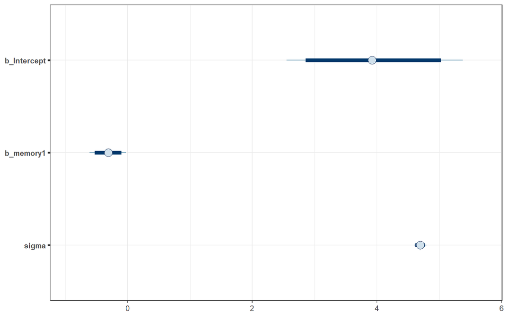

```r
mcmc_intervals(posterior_mod,
  pars = coeffsall$value[coeffsall$FE],
  prob = 0.95,
  prob_outer = 0.99,
  point_est = "mean")
```

# individual effect

predicted **memory** effect (with individual random effects)

```r
# str(posterior_mod)
# matrix[iterations, chains, parameters]
# and find position in parameter list
coeffsall <- coeffsall %>%
  mutate(coeff = rowMeans(matrix(posterior_mod,
                                 nrow=dim(posterior_mod)[3], byrow = TRUE)),
         now_compare = grepl(paste0("b_", now_cond, "1"), value),
         now_compare_id = grepl(paste0("r_id\\[\\d+,", now_cond, "1\\]"), value))
idcodes <- unique(mod_h$data$id)

# comparison coeff
compcoef <- coeffsall$coeff[coeffsall$now_compare]

REid <- coeffsall %>%
  filter(now_compare_id) %>%
  mutate(id = idcodes,
         effect = all_of(now_cond),
         RE = coeff + compcoef) %>%
  select(effect, id, RE)
```

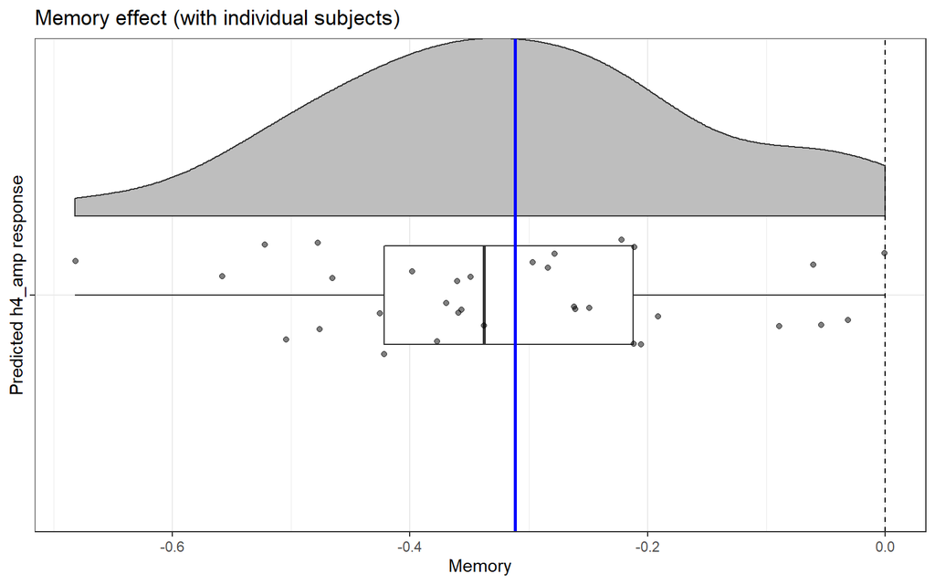

```r
REid %>%
  ggplot(aes(x = effect, y = RE)) +
  geom_violinhalf(position = position_nudge(x = .2, y = 0), fill = "gray") +
  coord_flip() +
  geom_boxplot(width = .25, outlier.shape = NA ) +
  geom_jitter(alpha = 0.5, width = 0.15) +
  theme(legend.position = "none",
        axis.text.y=element_blank()) + # remove now_compare label
  geom_hline(aes(yintercept = compcoef), color = "blue", size = 1) +
  geom_hline(aes(yintercept = 0), linetype = "dashed") +
  labs(title = paste0(str_to_title(now_cond), " effect (with individual subjects)"),
       x = paste0("Predicted ", now_EEG, " response"),
       y = str_to_title(now_cond))
```

# diagnostics

```r
diagnostic_posterior(mod_h) %>%
  kable() %>%
  kable_styling()
```

| Parameter | Rhat | ESS | MCSE |
| --- | --- | --- | --- |
| b_Intercept | 1.0083079 | 309.1981 | 0.0304405 |
| b_memory1 | 0.9999083 | 3656.4757 | 0.0018254 |

# PPC

posterior predictive check

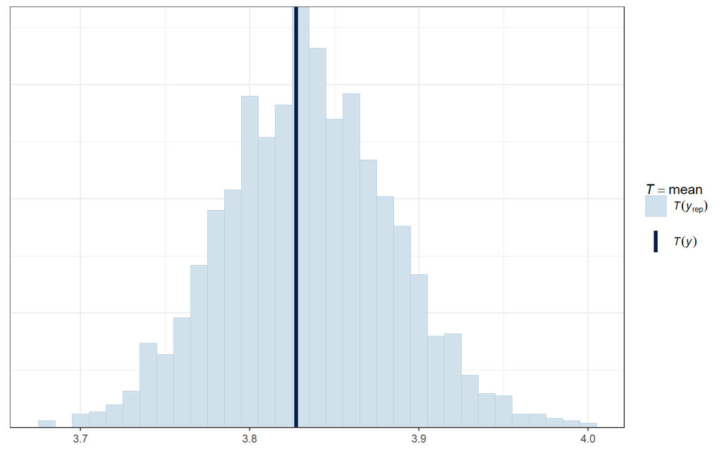

```r
y <- df[[now_EEG]] # actual outcome variable
yrep <- posterior_predict(mod_h,  # predicted outcome
                          ndraws = my_iter) # default = 4000 draws
ppc_stat(y,     # actual outcome variable
         yrep,  # predicted outcome
         stat = "mean",
         binwidth = .01)
```

plot 100 draws

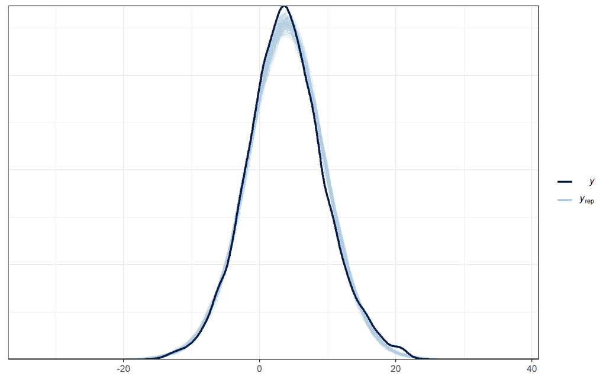

```r
ppc_dens_overlay(y, yrep[1:100,]) # plot some draws
```

# prior

definition of all priors

note: to compute the BF, the prior must be defined explicitly when computing the model.

```r
prior_descr <- describe_prior(mod_h)
prior_descr %>%
      kable() %>%
      kable_styling()
```

| Parameter | Prior_Distribution | Prior_Location | Prior_Scale | Prior_df |
| --- | --- | --- | --- | --- |
| b_Intercept | student_t | 3.7 | 5.5 | 3 |
| b_memory1 | normal | 0.0 | 2.0 | NA |
| sd_id__Intercept | student_t | 0.0 | 5.5 | 3 |
| sd_id__memory1 | student_t | 0.0 | 5.5 | 3 |
| cor_id__Intercept__memory1 | lkj | 1.0 | NA | NA |
| cor_id__Intercept__memory1 | gamma | NA | NA | NA |
| sigma | student_t | 0.0 | 5.5 | 3 |
| prior_Intercept | gamma | NA | NA | NA |
| prior_b | gamma | NA | NA | NA |
| prior_sigma | gamma | NA | NA | NA |
| prior_sigma | student_t | 0.0 | 5.5 | 3 |
| prior_nu | gamma | NA | NA | NA |
| prior_sd_id | gamma | NA | NA | NA |
| prior_cor_id | gamma | NA | NA | NA |

# factor definition

comparison: **memory**

show factor and contrast

```r
df %>%
  select(-now_compare) %>%
  select(where(is.factor)) %>%
  purrr::map(contrasts)
```

```
## $memory
##            [,1]
## remembered  0.5
## forgotten  -0.5
```

# outcome specifications

```r
df_outcome_spec %>%
  kable(align = "l") %>%
  kable_styling(bootstrap_options = c("striped", "hover", "condensed"))
```

| Feature | Value |
| --- | --- |
| interval (ms) | 160 - 210 |
| electrodes | P1, P3, P5, P7, P9, PO7, PO3, O1 |
| frequency | NA |

# **Bayes indexes**

ROPE = -0.1, 0.1

```r
tmpfile <- paste0("results/BFobjects/bf_indexes_",now_h, "_stage", now_stage, ".RData")
if (!file.exists(tmpfile)) {
  bf_indexes <- describe_posterior(mod_h,
                     centrality = "median",
                     effects = "fixed",
                     rope_range = now_ROPE,
                     rope_ci = 1,
                     test = c("p_direction", "rope", "bayesfactor"))
  saveRDS(bf_indexes, file = tmpfile)
} else{
  # read in existing file
  bf_indexes <- readRDS(tmpfile)
}
rm(tmpfile)

bf_indexes <- bf_indexes %>%
  filter(Parameter != "b_Intercept") %>%
  select(-Parameter) %>%
  rename(log_BF10 = log_BF) %>%
  mutate(BF10 = exp(log_BF10),
         BF01 = 1/BF10) %>%
  relocate(BF10:BF01, .after = log_BF10)
bf_indexes %>%
  pivot_longer(cols = Median:ESS, names_to = "Measure", values_to = "Value") %>%
  kable() %>%
  kable_styling()
```

| Measure | Value |
| --- | --- |
| Median | -0.3119047 |
| CI | 0.9500000 |
| CI_low | -0.5309671 |
| CI_high | -0.1047008 |
| pd | 0.9972500 |
| ROPE_CI | 1.0000000 |
| ROPE_low | -0.1000000 |
| ROPE_high | 0.1000000 |
| ROPE_Percentage | 0.0247500 |
| log_BF10 | 0.8838470 |
| BF10 | 2.4201924 |
| BF01 | 0.4131903 |
| Rhat | 0.9999083 |
| ESS | 3656.4756712 |

# posterior plot

visualize posterior (add median and SD)

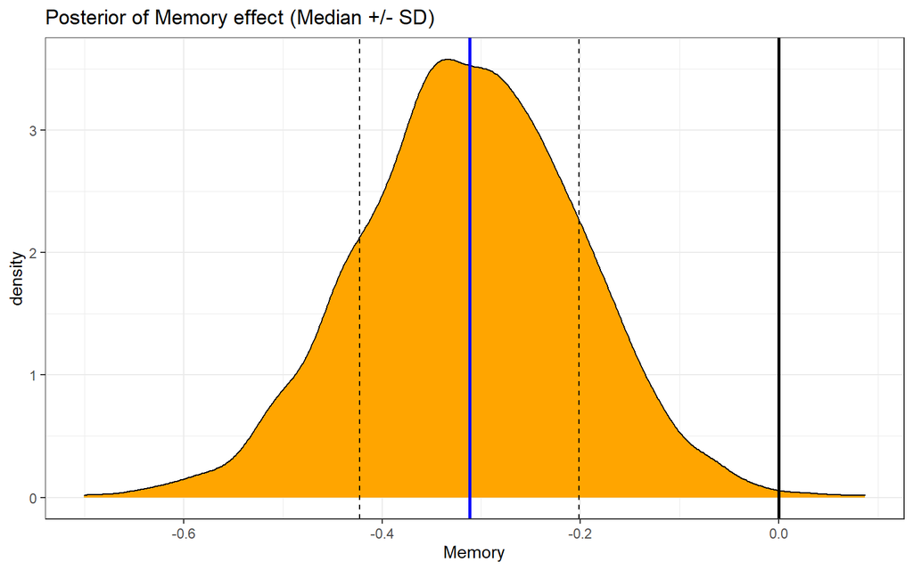

```r
posteriors <-  insight::get_parameters(mod_h)
post_sd <- sd(posteriors[[paste0("b_", now_cond, "1")]])
post_m <- median(posteriors[[paste0("b_", now_cond, "1")]])
ggplot(posteriors, aes(x = get(paste0("b_", now_cond, "1")))) +
  geom_density(fill = "orange") +
  geom_vline(aes(xintercept = post_m), linetype = "solid",
             color = "blue", size = 1) +
  geom_vline(aes(xintercept = post_m - post_sd), linetype = "dashed") +
  geom_vline(aes(xintercept = post_m + post_sd), linetype = "dashed") +
  geom_vline(aes(xintercept = 0), color = "black", linetype = "solid", size = 1) +
  labs(title = paste0("Posterior of ", str_to_title(now_cond), " effect (Median +/- SD)"),
               x = str_to_title(now_cond))
```

```r
post_cond <- posteriors$b_category1
```

# BF10 point null

Bayes factor for point null (0)

Note: The BF10 may deviate from that in the Bayesian indexes table because the posterior is resampled.

```r
tmpfile <- paste0("results/BFobjects/bf_null_",now_h, "_stage", now_stage, ".RData")
if (!file.exists(tmpfile)) {
  bf_null <- bayesfactor_parameters(mod_h,
                         effects = "fixed",
                         null = 0)
  saveRDS(bf_null, file = tmpfile)
} else{
  # read in existing file
  bf_null <- readRDS(tmpfile)
}
rm(tmpfile)

bf_null <- bf_null %>%
  filter(Parameter != "b_Intercept")
bf_null$Parameter <- now_cond
bf_null
```

```
## Bayes Factor (Savage-Dickey density ratio)
##
## Parameter | Effects |   Component |   BF
## ----------------------------------------
## memory    |   fixed | conditional | 2.37
##
## * Evidence Against The Null: 0
```

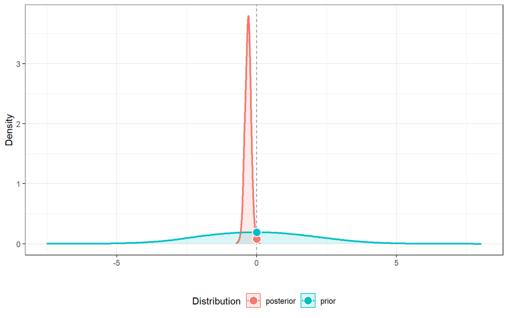

```r
plot(bf_null, size_point = 4)
```

```r
bf_null <- exp(bf_null$log_BF)
# do not use this later; use BF10 from Bayesian indexes table instead
```

# BF10 for ROPE

Bayes factor for ROPE

ROPE = -0.1, 0.1

```r
tmpfile <- paste0("results/BFobjects/bf_rope_",now_h, "_stage", now_stage, ".RData")
if (!file.exists(tmpfile)) {
  bf_rope <- bayesfactor_parameters(mod_h,
                         effects = "fixed",
                         null = now_ROPE)
  saveRDS(bf_rope, file = tmpfile)
} else{
  # read in existing file
  bf_rope <- readRDS(tmpfile)
}
rm(tmpfile)

bf_rope <- bf_rope %>%
  filter(Parameter != "b_Intercept")
bf_rope$Parameter <- now_cond
bf_rope
```

```
## Bayes Factor (Null-Interval)
##
## Parameter | Effects |   Component |   BF
## ----------------------------------------
## memory    |   fixed | conditional | 1.56
##
## * Evidence Against The Null: [-0.100, 0.100]
```

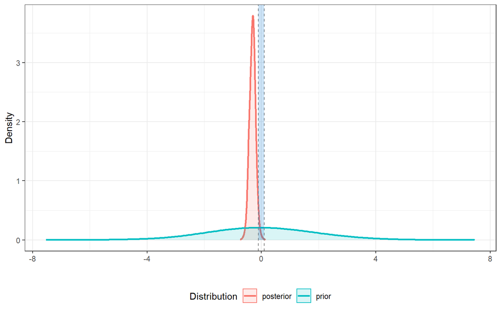

```r
plot(bf_rope, size_point = 4)
```

```r
bf_rope <- exp(bf_rope$log_BF)
```

# prepare next prior

extract prior and posterior

## prior

```r
prior_cond <- prior_descr %>%
  filter(Parameter == paste0("b_", now_cond, "1"))
prior_cond %>%
  kable() %>%
  kable_styling()
```

| Parameter | Prior_Distribution | Prior_Location | Prior_Scale | Prior_df |
| --- | --- | --- | --- | --- |
| b_memory1 | normal | 0 | 2 | NA |

```r
prior_distr <- prior_cond$Prior_Distribution
prior_m <- prior_cond$Prior_Location
prior_sd <- prior_cond$Prior_Scale
stopifnot("Prior is not a normal distribution" = prior_distr == "normal")
prior_cond <- distribution_normal(4000, mean = prior_m, sd = prior_sd, random = FALSE)
```

## posterior

posterior may be used as prior in next stage (as described by Stefan et al., 2022)

`data`: obtained posterior distribution

`normal`: median and SD from the data distribution are used to define a normal distribution (m = median, SD = SD).

`normal_scaled`: median and SD x 3 (i.e., SD = 3 x SD) from the data distribution are used to define a normal distribution.

goal is to show that the normal distribution fits the data well enough. Note that it is the m and SD that are saved. If these are used as the prior for a later analysis, the SD may be multiplied by a scaling factor (to avoid overfitting). Therefore, the figure also shows the normal with a scaling factor of 3 (i.e., SD = 3 x SD).

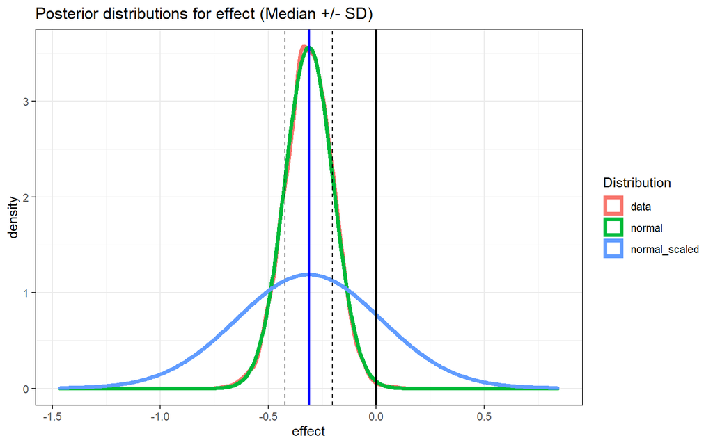

```r
post_distr <- distribution_normal(4000, mean = post_m, sd = post_sd, random = FALSE)
post_distr3 <- distribution_normal(4000, mean = post_m,
                                   sd = post_sd * now_scaling, random = FALSE)
bfdata <- tibble(data = posteriors[[paste0("b_", now_cond, "1")]],
                 normal = post_distr,
                 normal_scaled = post_distr3) %>%
  pivot_longer(cols = everything(),
               names_to = "Distribution",
               values_to = "effect")
ggplot(bfdata) +
  geom_density(aes(x = effect, color = Distribution), size = 1.5) +
  geom_vline(aes(xintercept = post_m), linetype = "solid",
             color = "blue", size = 1) +
  geom_vline(aes(xintercept = post_m - post_sd), linetype = "dashed") +
  geom_vline(aes(xintercept = post_m + post_sd), linetype = "dashed") +
  geom_vline(aes(xintercept = 0), color = "black", linetype = "solid", size = 1) +
  labs(title = paste0("Posterior distributions for effect (Median +/- SD)"))
```

# potential next prior

scaling factor: **3** x SD

rescaled posterior may be used as new prior in next stage

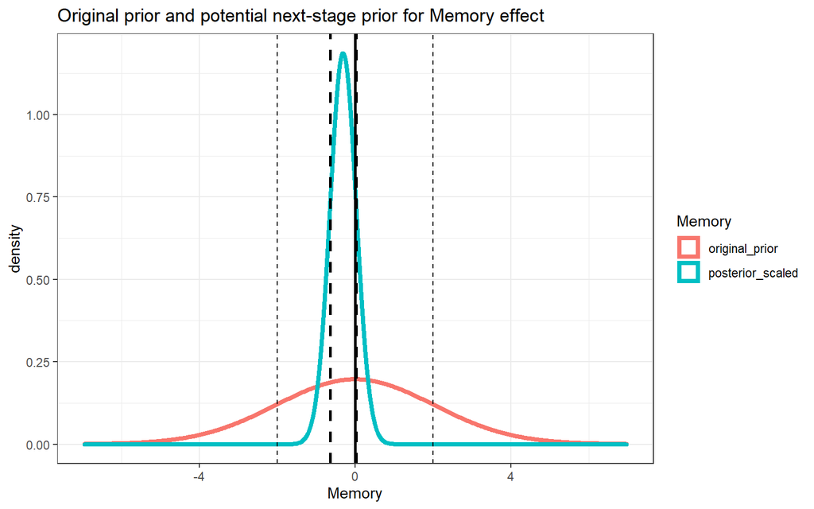

```r
# posterior computed earlier
bfdata <- tibble(original_prior = prior_cond,
                 posterior = post_cond,
                 posterior_scaled = post_distr3) %>%
  pivot_longer(cols = everything(),
               names_to = now_cond,
               values_to = "effect")
ggplot(bfdata) +
  geom_density(aes(x = effect, color = get(now_cond)), size = 1.5) +
  geom_vline(aes(xintercept = 0), color = "black", linetype = "solid", size = 1) +
  geom_vline(aes(xintercept = prior_m - prior_sd),
             color = "black", linetype = "dashed") +
  geom_vline(aes(xintercept = prior_m + prior_sd),
             color = "black", linetype = "dashed") +
  geom_vline(aes(xintercept = post_m - post_sd * now_scaling),
             color = "black", linetype = "dashed", size = 1) +
  geom_vline(aes(xintercept = post_m + post_sd * now_scaling),
             color = "black", linetype = "dashed", size = 1) +
  labs(title = paste0("Original prior and potential next-stage prior for ", str_to_title(now_cond), " effect"),
       x = str_to_title(now_cond),
       color = str_to_title(now_cond))
```

# simplified BF

posterior is described by a normal distribution with m = median and sd = sd

double check BF computations (see Bayes indexes)

**ROPE**: -0.1, 0.1

```r
BF10null <- dnorm(0, mean = prior_m, sd = prior_sd) / dnorm(0, mean = post_m, sd = post_sd)
BF10rope <- (pnorm(now_ROPE[2], mean = prior_m, sd = prior_sd) -
             pnorm(now_ROPE[1], mean = prior_m, sd = prior_sd)) /
            (pnorm(now_ROPE[2], mean = post_m, sd = post_sd) -
             pnorm(now_ROPE[1], mean = post_m, sd = post_sd))
data.frame(Analysis = c("by hand", "bayestestR"),
           BF10_null = c(BF10null, bf_indexes$BF10),
           BF01_null = c(1/BF10null, 1/bf_indexes$BF10),
           BF10_ROPE = c(BF10rope, bf_rope),
           BF01_ROPE = c(1/BF10rope, 1/bf_rope)) %>%
  kable(digits = 1) %>%
  kable_styling()
```

| Analysis | BF10_null | BF01_null | BF10_ROPE | BF01_ROPE |
| --- | --- | --- | --- | --- |
| by hand | 3.0 | 0.3 | 1.5 | 0.7 |
| bayestestR | 2.4 | 0.4 | 1.6 | 0.6 |

# save values

file: `prior_posterior`

save Bayes indexes

save prior and posterior described by normal distributions (m, sd)

table of saved data

hypothesis h4_amp, stage 3, predictor memory, outcome h4_amp

```r
df_distr_now <- tibble(Number = now_num,       # order of hypotheses
                       Hypothesis = now_h,
                       Stage = now_stage,
                       Predictor = now_cond,
                       Outcome = now_EEG,
                       Prior_m = prior_m,
                       Prior_sd = prior_sd,
                       Posterior_m = post_m,
                       Posterior_sd = post_sd)
df_distr_now <- cbind(df_distr_now, bf_indexes)

# add two-tailed p value (on the basis of pd)
df_distr_now$pd2tail <- 2 * (1 - df_distr_now$pd)


# add BF ROPE
df_distr_now$BF10_ROPE <- bf_rope
df_distr_now$BF01_ROPE <- 1/bf_rope
df_distr_now <- df_distr_now %>%
  relocate(pd2tail, .after = pd) %>%
  relocate(c(BF10_ROPE, BF01_ROPE), .before = Rhat)

df_distr_now %>%
  select(-c(Hypothesis:Outcome)) %>%
  pivot_longer(cols = everything(), names_to = "Measure", values_to = "Value") %>%
  kable(digits = 3) %>%
  kable_styling()
```

| Measure | Value |
| --- | --- |
| Number | 7.000 |
| Prior_m | 0.000 |
| Prior_sd | 2.000 |
| Posterior_m | -0.312 |
| Posterior_sd | 0.110 |
| Median | -0.312 |
| CI | 0.950 |
| CI_low | -0.531 |
| CI_high | -0.105 |
| pd | 0.997 |
| pd2tail | 0.006 |
| ROPE_CI | 1.000 |
| ROPE_low | -0.100 |
| ROPE_high | 0.100 |
| ROPE_Percentage | 0.025 |
| log_BF10 | 0.884 |
| BF10 | 2.420 |
| BF01 | 0.413 |
| BF10_ROPE | 1.563 |
| BF01_ROPE | 0.640 |
| Rhat | 1.000 |
| ESS | 3656.476 |

```r
if (!file.exists("results/prior_posterior.tsv")){
  write_delim(df_distr_now, paste0("results/prior_posterior.tsv"), delim = "\t")
} else{

  # read existing file
  df_distr <- read_delim("results/prior_posterior.tsv", delim = "\t",
                          show_col_types = FALSE)

    # find row for hypothesis and stage
  df_distr$check <- (df_distr$Hypothesis == now_h) &
                    (df_distr$Stage == now_stage)

  # delete this row
  df_distr <- df_distr %>%
    filter(!df_distr$check) %>%
    select(-check)

  # add data
  df_distr <- rbind(df_distr, df_distr_now) %>%
    arrange(Number, Hypothesis, Stage)

  write_delim(df_distr, paste0("results/prior_posterior.tsv"),
              delim = "\t", append = FALSE)
}
```

# package citations

```r
report::cite_packages()
```

```
##   - Ben Bolker and David Robinson (2022). broom.mixed: Tidying Methods for Mixed Models. R package version 0.2.9.3. https://CRAN.R-project.org/package=broom.mixed
##   - Dirk Eddelbuettel and Romain Francois (2011). Rcpp: Seamless R and C++ Integration. Journal of Statistical Software, 40(8), 1-18, <doi:10.18637/jss.v040.i08>.
##   - Gabry J, Mahr T (2022). "bayesplot: Plotting for Bayesian Models." R package version1.9.0, <URL: https://mc-stan.org/bayesplot/>.
##   - H. Wickham. ggplot2: Elegant Graphics for Data Analysis. Springer-Verlag New York, 2016.
##   - Hadley Wickham (2019). stringr: Simple, Consistent Wrappers for Common String Operations. R package version 1.4.0. https://CRAN.R-project.org/package=stringr
##   - Hadley Wickham and Maximilian Girlich (2022). tidyr: Tidy Messy Data. R package version 1.2.0. https://CRAN.R-project.org/package=tidyr
##   - Hadley Wickham, Jim Hester and Jennifer Bryan (2022). readr: Read Rectangular Text Data. R package version 2.1.2. https://CRAN.R-project.org/package=readr
##   - Hadley Wickham, Romain François, Lionel Henry and Kirill Müller (2022). dplyr: A Grammar of Data Manipulation. R package version 1.0.8. https://CRAN.R-project.org/package=dplyr
##   - Hao Zhu (2021). kableExtra: Construct Complex Table with 'kable' and Pipe Syntax. R package version 1.3.4. https://CRAN.R-project.org/package=kableExtra
##   - Kirill Müller and Hadley Wickham (2021). tibble: Simple Data Frames. R package version 3.1.6. https://CRAN.R-project.org/package=tibble
##   - Lüdecke D, Waggoner P, Makowski D (2019). "insight: A Unified Interface to AccessInformation from Model Objects in R." _Journal of Open Source Software_, *4*(38),1412. doi: 10.21105/joss.01412 (URL: https://doi.org/10.21105/joss.01412).
##   - Lüdecke et al., (2021). see: An R Package for Visualizing Statistical Models. Journal of Open Source Software, 6(64), 3393. https://doi.org/10.21105/joss.03393
##   - Makowski, D., Ben-Shachar, M., & Lüdecke, D. (2019). bayestestR: Describing Effects and their Uncertainty, Existence and Significance within the Bayesian Framework. Journal of Open Source Software, 4(40), 1541. doi:10.21105/joss.01541
##   - Makowski, D., Ben-Shachar, M.S., Patil, I. & Lüdecke, D. (2020). Automated Results Reporting as a Practical Tool to Improve Reproducibility and Methodological Best Practices Adoption. CRAN. Available from https://github.com/easystats/report. doi: .
##   - Paul-Christian Bürkner (2017). brms: An R Package for Bayesian Multilevel Models Using Stan. Journal of Statistical Software, 80(1), 1-28. doi:10.18637/jss.v080.i01
##   - R Core Team (2022). R: A language and environment for statistical computing. R Foundation for Statistical Computing, Vienna, Austria. URL https://www.R-project.org/.
```